# Assignment 5

### Week 5 Assignment Submission - K.Maadhu

### Calculate Petrol Consumption using Decision Trees - Regression

```python
import pandas as pd
import numpy as np
import os
from sklearn.model_selection import train_test_split
from sklearn.tree import DecisionTreeRegressor
from sklearn.model_selection import GridSearchCV
```

```python
os.chdir(r'C:\Maadhu\Jigsaw\Assignments\UC\AA&ML\Week 5')
```

**Read the input data of petrol consumption.**

```python
petrol_data = pd.read_csv('petrol_consumption.csv')
```

```python
petrol_data.head()
```

|  | Petrol_tax | Average_income | Paved_Highways | Population_Driver_licence(%) | Petrol_Consumption |
| --- | --- | --- | --- | --- | --- |
| 0 | 9.0 | 3571 | 1976 | 0.525 | 541 |
| 1 | 9.0 | 4092 | 1250 | 0.572 | 524 |
| 2 | 9.0 | 3865 | 1586 | 0.580 | 561 |
| 3 | 7.5 | 4870 | 2351 | 0.529 | 414 |
| 4 | 8.0 | 4399 | 431 | 0.544 | 410 |

**In the given dataset, 'Petrol_Consumption' is the target variable.**

#### Review the correlation between all the variables present in the dataset

```python
petrol_data.corr()
```

|  | Petrol_tax | Average_income | Paved_Highways | Population_Driver_licence(%) | Petrol_Consumption |
| --- | --- | --- | --- | --- | --- |
| Petrol_tax | 1.000000 | 0.012665 | -0.522130 | -0.288037 | -0.451280 |
| Average_income | 0.012665 | 1.000000 | 0.050163 | 0.157070 | -0.244862 |
| Paved_Highways | -0.522130 | 0.050163 | 1.000000 | -0.064129 | 0.019042 |
| Population_Driver_licence(%) | -0.288037 | 0.157070 | -0.064129 | 1.000000 | 0.698965 |
| Petrol_Consumption | -0.451280 | -0.244862 | 0.019042 | 0.698965 | 1.000000 |

Split the dataset into train and test on a 70:30 basis using a random seed of 2.

```python
X_Train, X_Test, y_Train, y_Test = train_test_split(petrol_data.drop('Petrol_Consumption', axis=1), petrol_data['Petrol_Consumption'], test_size = 0.3, random_state = 2)
```

Prepare the list of values used as the **hyper-parameters** for the GridSearch Cross-Validation

The values used for max_depth are 2,3,4,5 and None. The values used for max_features are 1,2,3 and 4.

```python
grid_params = [{"max_depth":[2,3,4,5,None], "max_features":[1,2,3,4]}]
```

**Grid Search Cross-Validation**

Run the Grid serach Cross validation for the Decision tree Regression alogorithm using a random seed value of 2.

Run the algorithm for the cross-validation with K-fold value of 5 and the above initialised hyper-parameters.

```python
gs = GridSearchCV(estimator=DecisionTreeRegressor(random_state=2), param_grid=grid_params, cv=5)
```

**Fit the model to our training dataset and display the output along with the best executing parameters.**

```python
gs.fit(X_Train, y_Train)
```

```
GridSearchCV(cv=5, error_score='raise',
       estimator=DecisionTreeRegressor(criterion='mse', max_depth=None, max_features=None,
           max_leaf_nodes=None, min_impurity_decrease=0.0,
           min_impurity_split=None, min_samples_leaf=1,
           min_samples_split=2, min_weight_fraction_leaf=0.0,
           presort=False, random_state=2, splitter='best'),
       fit_params=None, iid=True, n_jobs=1,
       param_grid=[{'max_depth': [2, 3, 4, 5, None], 'max_features': [1, 2, 3, 4]}],
       pre_dispatch='2*n_jobs', refit=True, return_train_score='warn',
       scoring=None, verbose=0)
```

```python
gs.cv_results_['params']
```

```
[{'max_depth': 2, 'max_features': 1},
 {'max_depth': 2, 'max_features': 2},
 {'max_depth': 2, 'max_features': 3},
 {'max_depth': 2, 'max_features': 4},
 {'max_depth': 3, 'max_features': 1},
 {'max_depth': 3, 'max_features': 2},
 {'max_depth': 3, 'max_features': 3},
 {'max_depth': 3, 'max_features': 4},
 {'max_depth': 4, 'max_features': 1},
 {'max_depth': 4, 'max_features': 2},
 {'max_depth': 4, 'max_features': 3},
 {'max_depth': 4, 'max_features': 4},
 {'max_depth': 5, 'max_features': 1},
 {'max_depth': 5, 'max_features': 2},
 {'max_depth': 5, 'max_features': 3},
 {'max_depth': 5, 'max_features': 4},
 {'max_depth': None, 'max_features': 1},
 {'max_depth': None, 'max_features': 2},
 {'max_depth': None, 'max_features': 3},
 {'max_depth': None, 'max_features': 4}]
```

```python
gs.cv_results_['rank_test_score']
```

```
array([17,  9, 14, 11, 18,  7,  2,  1, 16,  6,  4, 10, 19,  5, 12, 15, 20,
       13,  3,  8])
```

```python
print(gs.best_params_, gs.best_score_)
```

```
{'max_depth': 3, 'max_features': 4} 0.445715510049336
```

```python
gs.best_estimator_
```

```
DecisionTreeRegressor(criterion='mse', max_depth=3, max_features=4,
           max_leaf_nodes=None, min_impurity_decrease=0.0,
           min_impurity_split=None, min_samples_leaf=1,
           min_samples_split=2, min_weight_fraction_leaf=0.0,
           presort=False, random_state=2, splitter='best')
```

Use the above model to predict the values for the test dataset and evaluate using Mean Absolute Error and $R^2$ scores.

```python
predictions = gs.best_estimator_.predict(X_Test)
```

```python
from sklearn.metrics import mean_absolute_error, r2_score
```

```python
mean_absolute_error(y_Test, predictions)
```

```
43.860476190476184
```

```python
r2_score(y_Test, predictions)
```

```
-0.08768599225611418
```

**Export the above best fitted model to a tree like graphical representation using the Graphviz package.**

```python
from sklearn.tree import export_graphviz
```

```python
gs_data = export_graphviz(gs.best_estimator_, filled = True, rounded = False, feature_names = X_Train.columns, out_file = None)
```

```python
import graphviz
```

```python
graphviz.Source(gs_data)
```

[figure not shown]

### Identify counterfiet bills using DecisionTrees - Classifier

```python
from sklearn.tree import DecisionTreeClassifier
```

**Read the bill authentication dataset which has the Class column as the target.**

```python
bill_data = pd.read_csv('bill_authentication.csv')
```

```python
bill_data.head()
```

|  | Variance | Skewness | Curtosis | Entropy | Class |
| --- | --- | --- | --- | --- | --- |
| 0 | 3.62160 | 8.6661 | -2.8073 | -0.44699 | 0 |
| 1 | 4.54590 | 8.1674 | -2.4586 | -1.46210 | 0 |
| 2 | 3.86600 | -2.6383 | 1.9242 | 0.10645 | 0 |
| 3 | 3.45660 | 9.5228 | -4.0112 | -3.59440 | 0 |
| 4 | 0.32924 | -4.4552 | 4.5718 | -0.98880 | 0 |

#### Identify the correlation between all the variables before fitting the model

```python
bill_data.corr()
```

|  | Variance | Skewness | Curtosis | Entropy | Class |
| --- | --- | --- | --- | --- | --- |
| Variance | 1.000000 | 0.264026 | -0.380850 | 0.276817 | -0.724843 |
| Skewness | 0.264026 | 1.000000 | -0.786895 | -0.526321 | -0.444688 |
| Curtosis | -0.380850 | -0.786895 | 1.000000 | 0.318841 | 0.155883 |
| Entropy | 0.276817 | -0.526321 | 0.318841 | 1.000000 | -0.023424 |
| Class | -0.724843 | -0.444688 | 0.155883 | -0.023424 | 1.000000 |

```python
del(X_Train, X_Test, y_Train, y_Test, gs, grid_params, predictions, gs_data)
```

Split the dataset into training and test in a 70:30 approach with 2 as the random seed value.

```python
X_Train, X_Test, y_Train, y_Test = train_test_split(bill_data.drop(['Class'], axis=1), bill_data['Class'], test_size = 0.3, random_state = 2)
```

Initialize the values for the **hyper-parameters** for max_depth as 4, 5, 6 and 'None' and max_features as 2, 3 and 4.

```python
grid_params = [{'max_depth':[4,5,6, None], 'max_features':[2,3,4]}]
```

Run the Grid Search Cross Validation for the Decision Tree Classification algorithm with K-fold value of 5 and the above hyper-parameters

```python
gs = GridSearchCV(estimator=DecisionTreeClassifier(random_state=2), param_grid=grid_params, cv=5)
```

**Fit the model with the training set of the data and generate the best executing parameters.**

```python
gs.fit(X_Train ,y_Train)
```

```
GridSearchCV(cv=5, error_score='raise',
       estimator=DecisionTreeClassifier(class_weight=None, criterion='gini', max_depth=None,
            max_features=None, max_leaf_nodes=None,
            min_impurity_decrease=0.0, min_impurity_split=None,
            min_samples_leaf=1, min_samples_split=2,
            min_weight_fraction_leaf=0.0, presort=False, random_state=2,
            splitter='best'),
       fit_params=None, iid=True, n_jobs=1,
       param_grid=[{'max_depth': [4, 5, 6, None], 'max_features': [2, 3, 4]}],
       pre_dispatch='2*n_jobs', refit=True, return_train_score='warn',
       scoring=None, verbose=0)
```

```python
gs.cv_results_['params']
```

```
[{'max_depth': 4, 'max_features': 2},
 {'max_depth': 4, 'max_features': 3},
 {'max_depth': 4, 'max_features': 4},
 {'max_depth': 5, 'max_features': 2},
 {'max_depth': 5, 'max_features': 3},
 {'max_depth': 5, 'max_features': 4},
 {'max_depth': 6, 'max_features': 2},
 {'max_depth': 6, 'max_features': 3},
 {'max_depth': 6, 'max_features': 4},
 {'max_depth': None, 'max_features': 2},
 {'max_depth': None, 'max_features': 3},
 {'max_depth': None, 'max_features': 4}]
```

```python
gs.cv_results_['rank_test_score']
```

```
array([12, 11, 10,  9,  7,  6,  8,  4,  2,  5,  3,  1])
```

```python
print(gs.best_estimator_)
```

```
DecisionTreeClassifier(class_weight=None, criterion='gini', max_depth=None,
            max_features=4, max_leaf_nodes=None, min_impurity_decrease=0.0,
            min_impurity_split=None, min_samples_leaf=1,
            min_samples_split=2, min_weight_fraction_leaf=0.0,
            presort=False, random_state=2, splitter='best')
```

```python
print(gs.best_params_, gs.best_score_)
```

```
{'max_depth': None, 'max_features': 4} 0.98125
```

The above output shows that the beset fitting parameters for our model are with max_depth of 'None' and max_features of 4.

**Generate scores for the model.**

```python
from sklearn.metrics import accuracy_score, log_loss, precision_score, recall_score, f1_score
```

```python
predictions = gs.best_estimator_.predict(X_Test)
```

```python
accuracy_score(y_Test, predictions)
```

```
0.9781553398058253
```

The above fitted Grid Search CV Classifier model has an accuracy of 97.8%

```python
log_loss(y_Test, predictions)
```

```
0.7544994784921789
```

```python
precision_score(y_Test, predictions)
```

```
0.9696969696969697
```

```python
recall_score(y_Test, predictions)
```

```
0.9846153846153847
```

```python
f1_score(y_Test, predictions)
```

```
0.9770992366412214
```

Generate the **Confusion martix** based on the above predicted output from the Classifier algorithm.

```python
from sklearn.metrics import confusion_matrix
import seaborn as sb
```

```python
conf_mat = confusion_matrix(y_Test, predictions)
```

```python
confusion_df = pd.DataFrame(conf_mat, index=['Actual Neg','Actual Pos'], columns=['Predicted Neg','Predicted Pos'])
```

```python
confusion_df
```

|  | Predicted Neg | Predicted Pos |
| --- | --- | --- |
| Actual Neg | 211 | 6 |
| Actual Pos | 3 | 192 |

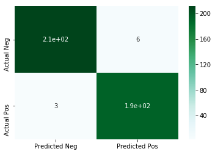

```python
_=sb.heatmap(confusion_df, cmap='BuGn', annot= True)
```

**Display the tree like graphical output for the above fitted model.**

```python
gs_data = export_graphviz(gs.best_estimator_, filled = False, rounded=True, feature_names=X_Train.columns, out_file=None)
```

```python
graphviz.Source(gs_data)
```

[figure not shown]